# Simulation of Metagenomic Data Generated from Gut Species

2022-12-22

To simulate mixtures of common gut bacteria we consider species taken from: Mu, A. et al. Reconstruction of the Genomes of Drug-Resistant Pathogens for Outbreak Investigation through Metagenomic Sequencing. mSphere, (2019)

The exact reference genomes used are available in the zip file attached to the release of this GitHub repository.

- *Akkermansia muciniphila* (GCF_000020225.1)
- *Bacteroides cellulosilyticus* (GCF_028539415.1)
- *Bacteroides uniformis* (GCF_025147485.1)
- *Enterocloster bolteae/Clostridium bolteae* (GCF_002234575.2)
- *Dialister invisus* (GCF_000160055.1)
- *Enterococcus faecium* (GCF_029023785.1)
- *Amedibacillus dolichus/Eubacterium dolichum* (GCF_000154285.1)
- *Klebsiella pneumoniae* (GCF_000742135.1)
- *Lactiplantibacillus pentosus* (GCF_003641185.1)
- *Parabacteroides merdae* (GCF_025151215.1)

We now run Skani to search each reference genome against the GTDB database to identify new references that are roughly 99% and 97% ANI to the original reference genomes. This is done to simulate a more realistic scenario where the reference genomes are more divergent from the database.

```
rm skani_cmds.txt
for f in gtdb_rep_references/*.fna
do
prefix=$(basename $f .fna)
echo "skani search --min-af 80 -s 95 -t 20 $f -d /data1/gerryt/sylph_analyses/GTDB_complete2/gtdb_skani_database_ani -o ./gtdb_search_results/${prefix}_gtdb_search_results.tsv" >> skani_cmds.txt
done

parallel --joblog parallel_skani_joblog.txt --progress -j 15 < skani_cmds.txt
```

```python
import pandas as pd
import shutil
import glob

metafile = "bac120_metadata_r220.tsv.gz"

df = pd.read_csv(metafile, sep='\t', low_memory=False)

# Fix accession
df["accession"] = df["accession"].str.extract('(GC[AF]_\d{9}\.\d)')

# Set overall score according to GTDB formula.
# The current GTDB representative is given the greatest score (1e7).

# GTDB CRITERIA: SCORE
# Assembled from type strain of species:                1 000 000
# Effective type strain of species according to NCBI:   100 000
# NCBI representative of species:                       10 000
# Assembled from type strain of subspecies:             1000
# Complete genome:                                      100
# CheckM quality estimate:                              Completeness – 5 × contamination
# MAG or SAG:                                           –100
# Contig count:                                         –5 × (no. contigs/100)
# Undetermined bases:                                   –5 × (no. undetermined bases/10 000)
# Full length 16S rRNA gene:                            10

df['rep_score'] = (
    1e7 * (df['gtdb_representative']=='t').astype(float) +
    1e6 * df['gtdb_type_designation_ncbi_taxa_sources'].str.contains("LPSN", na=False).astype(float) +
    1e5 * df['gtdb_type_designation_ncbi_taxa'].str.contains("type strain of species", na=False).astype(float) +
    1e4 * df['ncbi_refseq_category'].str.contains("representative genome", na=False).astype(float) +
    1e3 * df['gtdb_type_designation_ncbi_taxa'].str.contains("type strain of subspecies", na=False).astype(float) +
    1e2 * df['ncbi_assembly_level'].str.contains("Complete Genome", na=False).astype(float) +
    df['checkm_completeness'] - 5*df['checkm_contamination'] -
    100 * (df['mimag_high_quality']=='f').astype(float) -
    5 * (df['contig_count']/1e2) -
    5 * (df['ambiguous_bases']/1e4) +
    10 * (df['ssu_count']>0).astype(float)
)

df = df.sort_values(by='rep_score', ascending=False)

df['gtdb_species'] = df["gtdb_taxonomy"].str.extract('s__(.*)')


# Now look through Skani results and take the first under each ANI threshold that has a minimum GTDB score of 100
min_rep_score = 100
database_location = "/data1/gerryt/sylph_analyses/GTDB_complete2/2024-10-15_00-34-44/files/"

for skani_results in glob.glob("*_gtdb_search_results.tsv"):
    gtdb_rep = skani_results.split("_")[0]
    skani_df = pd.read_csv(skani_results, sep='\t', low_memory=False)
    skani_df["accession"] = skani_df["Ref_file"].str.extract('(GC[AF]_\d{9}\.\d)')
    skani_df = skani_df.merge(df[['accession', 'rep_score']], on='accession', how='left')
    skani_filtered = skani_df[skani_df['rep_score'] >= min_rep_score]
    skani_filtered = skani_filtered.sort_values(by='ANI', ascending=False)
    for A in [99, 97]:
        print(A)
        # Find the first row where ANI <= A
        accession_first_below_threshold = skani_filtered[skani_filtered['ANI'] <= A].head(1)
        # If no such row exists, fall back to row with minimum ANI
        if accession_first_below_threshold.empty:
            min_ani = skani_filtered['ANI'].min()
            accession_first_below_threshold = skani_filtered[skani_filtered['ANI'] == min_ani].head(1)
        accession_str = accession_first_below_threshold['accession'].tolist()[0]
        ani_str = str(accession_first_below_threshold['ANI'].tolist()[0])
        ref_file = glob.glob(database_location + accession_str + "*")[0]
        destination_file = "refs_" + str(A) + "/" + accession_str + "_gtdbrep_" + gtdb_rep + "_ani" + ani_str + "fna.gz"
        print(ref_file, destination_file, ani_str)
        shutil.copy2(ref_file, destination_file)
```

## Simulations

The following Bash commands accurately describe the execution process for each transmission inference method. However, they are not configured to run directly from this Rmarkdown document. Instead, these commands were executed separately on a server. The Python scripts for each tool can be found in the scripts directory of the TRACS package.

Here we simulate the transmission of each species separately at 5, 50 and 500 SNPs. The remaining species within each mixture are simulated to be separated by 10,000 SNPs on average.

```
for ref in ./gtdb_rep_references/*.fna
do
for d in 5 50 500
do
prefix=$(basename $ref .fna)
prefix=sim_d${d}_ref_${prefix}
echo python /data1/gerryt/tracs/scripts/tracs-sim.py -t 5 --genomes ./gtdb_rep_references/*.fna --tran-genome $ref -d $d -b 10000 -n 5 -o $prefix --prefix $prefix >> sim_gtdb_refs_cmds.txt
done
done

parallel --joblog parallel_sim_gtdb_refs_joblog.txt --progress -j 50 < sim_gtdb_refs_cmds.txt


rm sim_gtdb_refs_div_cmds.txt
for ref in ./refs_99/*.fna
do
for d in 5 50 500
do
prefix=$(basename $ref .fna)
prefix=sim_d${d}_ref_${prefix}
echo python /data1/gerryt/tracs/scripts/tracs-sim.py -t 5 --genomes ./refs_99/*.fna --tran-genome $ref -d $d -b 10000 -n 5 -o ./sim_99/${prefix} --prefix $prefix >> sim_gtdb_refs_div_cmds.txt
done
done

for ref in ./refs_97/*.fna
do
for d in 5 50 500
do
prefix=$(basename $ref .fna)
prefix=sim_d${d}_ref_${prefix}
echo python /data1/gerryt/tracs/scripts/tracs-sim.py -t 5 --genomes ./refs_97/*.fna --tran-genome $ref -d $d -b 10000 -n 5 -o ./sim_97/${prefix} --prefix $prefix >> sim_gtdb_refs_div_cmds.txt
done
done

parallel --joblog parallel_sim_div_gtdb_refs_joblog.txt --progress -j 60 < sim_gtdb_refs_div_cmds.txt
```

## Run tools

### TRACS

TRACS was run using both the full GTDB r207 database and a reduced database that only includes the genomes used in the simulation.

```
rm /data1/gerryt/tracm-data/simulations/meta_revision/all_tracs_cmds.txt
for folder in sim_100 sim_99 sim_97
do
cd $folder
folder_path=$(pwd)
for f in sim_d5*
do
  echo "prefix  read1 read2" > ${f}/input_data.csv
  echo "sampleA ${folder_path}/${f}/${f}_A1.fastq.gz ${folder_path}/${f}/${f}_A2.fastq.gz" >> ${folder_path}/${f}/input_data.csv
  echo "sampleB ${folder_path}/${f}/${f}_B1.fastq.gz ${folder_path}/${f}/${f}_B2.fastq.gz" >> ${folder_path}/${f}/input_data.csv
  echo tracs pipe -i ${folder_path}/${f}/input_data.csv -o ${folder_path}/tracs_filt_1cpu_${f} -t 1 --database /data1/gerryt/tracm-data/simulations/meta_revision/gtdb-rs207.genomic-reps.dna.k51.sbt.zip --keep-all --filter >> /data1/gerryt/tracm-data/simulations/meta_revision/all_tracs_cmds.txt
done
cd ..
done

parallel --joblog parallel_tracs_1cpu_cmds_joblog.txt --progress -j 90 < all_tracs_cmds.txt
```

Build a smaller database which only includes the genomes used in the simulation. These genomes are also used in the comparison against alternative tools.

```
tracs build-db -i ./gtdb_rep_references/*.fna -o tracs_db_same_genome_as_sim -t 10
```

[output not shown]

### StrainPhlAn

MetaPhlAn & StrainPhlAn v4.0.5 were run using the default database (mpa_vJan21_CHOCOPhlAnSGB_202103).

```
rm all_strainphlan_cmds.txt
for folder in sim_100 sim_99 sim_97
do
cd $folder
folder_path=$(pwd)
for f in sim_d5*
do
  echo python /data1/gerryt/tracs/scripts/run-strainphlan.py --inputA ${folder_path}/${f}/${f}_A1.fastq.gz ${folder_path}/${f}/${f}_A2.fastq.gz --inputB ${folder_path}/${f}/${f}_B1.fastq.gz ${folder_path}/${f}/${f}_B2.fastq.gz -o ${folder_path}/strainphlan_${f} -p ${f} -t 1 --refDB /data1/gerryt/tracm-data/simulations/metaphlan/metaphlanDB >> /data1/gerryt/tracm-data/simulations/meta_revision/all_strainphlan_cmds.txt
done
cd ..
done

parallel --joblog parallel_strainphlan_cmds_joblog.txt --progress -j 90 < all_strainphlan_cmds.txt
```

### StrainGE

StrainGE v1.3.3 was then run on each simulation

```
mkdir strainge_db

for f in ./gtdb_rep_references/*.fna
do
prefix=$(basename $f .fna)
straingst kmerize -o ./strainge_db/${prefix}.hdf5 $f
done

cd strainge_db
straingst kmersim --all-vs-all -t 4 -S jaccard -S subset *.hdf5 > similarities.tsv
straingst cluster -i similarities.tsv -d -C 0.99 -c 0.90 --clusters-out clusters.tsv *.hdf5 > references_to_keep.txt
straingst createdb -o pan-genome-db.hdf5 *.hdf5
cd ..
```

[output not shown]

### InStrain

inStrain v1.8.0 was run the same database.

```
rm all_instrain_cmds.txt
for folder in sim_100 sim_99 sim_97
do
cd $folder
folder_path=$(pwd)
for f in sim_d5*
do
  f=$(basename $f)
  echo python /data1/gerryt/tracs/scripts/run-instrain.py -t 1 --inputA ${folder_path}/${f}/${f}_A*.fastq.gz --inputB ${folder_path}/${f}/${f}_B*.fastq.gz --references /data1/gerryt/tracm-data/simulations/meta_revision/gtdb_rep_references/*.fna -o ${folder_path}/instrain_${f} -p ${f} >> /data1/gerryt/tracm-data/simulations/meta_revision/all_instrain_cmds.txt
done
cd ..
done

parallel --joblog parallel_instrain_cmds_joblog.txt --progress -j 90 < all_instrain_cmds.txt
```

## InStrain Assembly

First assemble everything with MetaSpades. This approach is not feasible for online transmission inference as all samples have to be available at the start of the analysis. However, it is useful for benchmarking the performance of the tools.

```
rm all_meta_spades_cmds.txt
# Loop over simulation folders
for folder in sim_100 sim_99 sim_97
do
cd $folder
folder_path=$(pwd)
for f in sim_d5*
do
  f=$(basename $f)
  echo "Processing: $f"
  A1="${folder_path}/${f}/${f}_A1.fastq.gz"
  A2="${folder_path}/${f}/${f}_A2.fastq.gz"
  B1="${folder_path}/${f}/${f}_B1.fastq.gz"
  B2="${folder_path}/${f}/${f}_B2.fastq.gz"
  cat ${A1} ${B1} > "${folder_path}/${f}/${f}_combined_1.fastq.gz"
  cat ${A2} ${B2} > "${folder_path}/${f}/${f}_combined_2.fastq.gz"
  OUT="${folder_path}/${f}/metaspades_combined_${f}"
  echo "metaspades.py -t 2 -1 ${folder_path}/${f}/${f}_combined_1.fastq.gz -2 ${folder_path}/${f}/${f}_combined_2.fastq.gz -o ${OUT}" >> /data1/gerryt/tracm-data/simulations/meta_revision/all_meta_spades_cmds.txt
done
cd ..
done

# Input FASTQ files for A and B
parallel --joblog parallel_metspades_combined_cmds_joblog.txt --progress -j 90   '/usr/bin/time -v bash -c {} 2> time_logs/job_{#}.log' :::: all_meta_spades_cmds.txt
```

Generate InStrain stb

```
rm /data1/gerryt/tracm-data/simulations/meta_revision/generate_stbs.txt
for folder in sim_100 sim_99 sim_97
do
cd $folder
folder_path=$(pwd)
for f in sim_d5*
do
  f=$(basename $f)
  echo "Processing: $f"
  meta_out="${folder_path}/${f}/metaspades_combined_${f}/scaffolds.fasta"
  mkdir -p "${folder_path}/${f}/metaspades_combined_${f}/species_scaffolds/"
  echo "/data1/gerryt/tracs/scripts/generate_instrain_stb.sh ${meta_out} /data1/gerryt/tracm-data/simulations/meta_revision/gtdb_rep_references/ ${folder_path}/${f}/metaspades_combined_${f}/instrain_map.stb ${folder_path}/${f}/metaspades_combined_${f}/species_scaffolds/" >> /data1/gerryt/tracm-data/simulations/meta_revision/generate_stbs.txt
done
cd ..
done

parallel --joblog parallel_generate_stbs_cmds_joblog.txt --progress -j 90 < generate_stbs.txt
```

Now run InStrain with custom references

```
rm all_instrain_customDB_cmds.txt
for folder in sim_100 sim_99 sim_97
do
cd $folder
folder_path=$(pwd)
for f in sim_d5*
do
  f=$(basename $f)
  meta_out="${folder_path}/${f}/metaspades_combined_${f}/scaffolds.fasta"
  echo python /data1/gerryt/tracs/scripts/run-instrain.py -t 1 --inputA ${folder_path}/${f}/${f}_A*.fastq.gz --inputB ${folder_path}/${f}/${f}_B*.fastq.gz --references ${folder_path}/${f}/metaspades_combined_${f}/species_scaffolds/*.fasta -o ${folder_path}/instrain_customDB_${f} -p ${f} >> /data1/gerryt/tracm-data/simulations/meta_revision/all_instrain_customDB_cmds.txt
done
cd ..
done


for folder in sim_100 sim_99 sim_97
do
  cd $folder
  folder_path=$(pwd)

  for f in sim_d5*
  do
    f=$(basename $f)
    output_dir="${folder_path}/instrain_customDB_${f}"
    summary_file="${output_dir}/compare_instrain_summary.tsv"

    if [ ! -f "$summary_file" ]; then
      meta_out="${folder_path}/${f}/metaspades_combined_${f}/scaffolds.fasta"
      echo python /data1/gerryt/tracs/scripts/run-instrain.py -t 10 \
        --inputA ${folder_path}/${f}/${f}_A*.fastq.gz \
        --inputB ${folder_path}/${f}/${f}_B*.fastq.gz \
        --references ${folder_path}/${f}/metaspades_combined_${f}/species_scaffolds/*.fasta \
        -o ${output_dir} -p ${f} >> /data1/gerryt/tracm-data/simulations/meta_revision/all_instrain_customDB_cmds3.txt
    fi
  done

  cd ..
done

parallel --joblog parallel_instrain_customDB_cmds_joblog3.txt --progress -j 3 < all_instrain_customDB_cmds3.txt
```

We can now combine the results files into a folder for analysis

```
for folder in sim_100 sim_99 sim_97
do
outdir="/data1/gerryt/tracm-data/simulations/meta_revision/meta_sim_mixtures/${folder}"
mkdir -p $outdir
cd $folder
folder_path=$(pwd)
for f in sim*
do
cp ${folder_path}/${f}/*_dist_props.csv ${outdir}/
done
for f in tracs*
do
  cp ${folder_path}/${f}/transmission_distances.csv ${outdir}/${f}_distances.csv
done
for f in strainge_*
do
    cp ${folder_path}/${f}/comparison.tsv ${outdir}/${f}_distances.tsv
done
for f in instrain_*
do
    cp ${folder_path}/${f}/compare_instrain_summary.tsv ${outdir}/${f}_distances.tsv
done
for f in instrain_customDB*
do
    cp ${folder_path}/${f}/compare_instrain_summary.tsv ${outdir}/${f}_distances.tsv
done
for f in  strainphlan*
do
  cp ${folder_path}/${f}/strainphlan_distances.tsv ${outdir}/${f}_distances.tsv
done
cd ..
done

tar -czf meta_sim_mixtures.tar.gz ./meta_sim_mixtures
```

## Compare results and generate plot

```r
library(data.table)
library(tidyverse)
library(ggthemes)
library(dplyr)
```

```r
# Load simulation distances
sim_dists <- map_dfr(Sys.glob("./data/meta_sim_mixtures/sim*/sim*_dist_props.csv"), ~{
  simulation <- gsub(".*/(sim_\\d+)/.*", "\\1", .x)
  return(fread(.x) %>%
    as_tibble() %>%
    add_column(simulation=simulation, .before = 1) %>%
    filter(distance <= 500))
})
sim_dists$genome <- gsub("_genomic", "", sim_dists$genome)
# Check we dont have any duplicated entries
stopifnot(all(!duplicated(sim_dists[,c(1,2,5)])))
```

```r
# Load StrainPhlAn results
sphlan_map <- read_csv("./data/strainphlan_db_map.csv")
sphlan_aln_dist <- read_csv("./data/meta_SGB_lengths.csv")
```

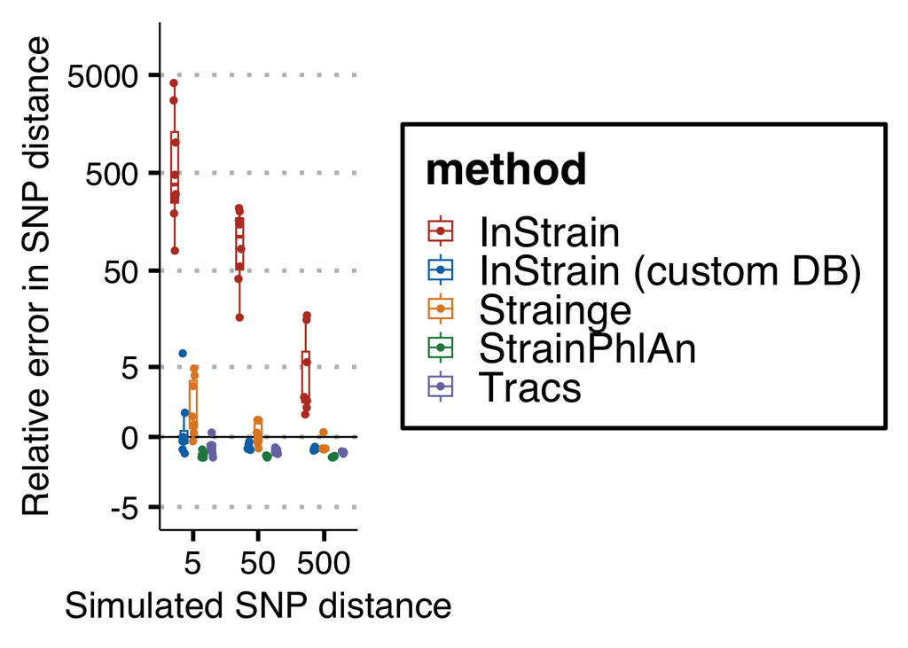

```r
strainphlan <- map_dfr(Sys.glob("./data/meta_sim_mixtures/sim*/strainphlan*_distances.tsv"), ~{
  simulation <- gsub(".*/(sim_\\d+)/.*", "\\1", .x)
  name <- gsub(".*_ref_", "", gsub("_g.*", "", .x))
  gtdb_accession <- str_extract(.x, "(?<=_gtdbrep_)(GCF_[^_]+)")
  if (is.na(gtdb_accession)) {
    gtdb_accession <- str_extract(.x, "(?<=_ref_)(GCF_[^_]+)")
  }

  df <- fread(.x, colClasses = c('character', 'character', 'character', 'integer')) %>%
    as_tibble() %>%
    add_column(sample=name, .before = 1) %>%
    add_column(gtdb_accession=gtdb_accession) %>%
    add_column(sim_dist=str_extract(.x, "(?<=_d)\\d+")) %>%
    add_column(simulation=simulation, .before=1)

  return(df)
}) %>%
add_column(method="StrainPhlAn")

strainphlan$gtdb_species <- sphlan_map$species[match(strainphlan$gtdb_accession, sphlan_map$ID)]

strainphlan <- strainphlan %>%
  filter(species==gtdb_species)

strainphlan$strain <- gsub("[AB]_", "", strainphlan$sample1)
strainphlan$genome_length <- sphlan_map$length[match(strainphlan$species, sphlan_map$species)]
strainphlan$scaled_snp_dist <- strainphlan$genome_length/sphlan_aln_dist$length[match(strainphlan$strain, sphlan_aln_dist$strain)] * strainphlan$snp_dist

# Load StrainGE results


col_types <- spec(read_tsv(Sys.glob("./data/meta_sim_mixtures/sim*/strainge*")[[1]]))$cols
strainge <- map_dfr(Sys.glob("./data/meta_sim_mixtures/sim*/strainge*"), ~{
  simulation <- gsub(".*/(sim_\\d+)/.*", "\\1", .x)
  name <- gsub(".*_ref_", "", gsub("_g.*", "", .x))

  gtdb_accession <- str_extract(.x, "(?<=_gtdbrep_)(GCF_[^_]+)")
  if (is.na(gtdb_accession)) {
    gtdb_accession <- str_extract(.x, "(?<=_ref_)(GCF_[^_]+)")
  }

  df <- read_tsv(.x, col_types = col_types) %>%
    as_tibble() %>%
    group_by(ref) %>%
    summarise(
      snpdist=sum(common-sharedAlleles)
    ) %>%
    filter(str_extract(ref, "^[^_]+_[^_]+")==gtdb_accession) %>%
    add_column(sim_dist=str_extract(.x, "(?<=_d)\\d+"), .before=1) %>%
    dplyr::rename(snp_dist = snpdist) %>%
    add_column(sample=name, .before = 1) %>%
    add_column(method="Strainge") %>%
    add_column(simulation=simulation, .before=1)

  df <- df[which.min(df$snp_dist),]

  return(df)
})

strainge$ref <- NULL


# Load TRACS results

col_types <- spec(read_csv(Sys.glob("./data/meta_sim_mixtures/sim*/tracs*")[[1]]))$cols
tracs <-  map_dfr(Sys.glob("./data/meta_sim_mixtures/sim*/tracs_filt_reduced*"), ~{
  simulation <- gsub(".*/(sim_\\d+)/.*", "\\1", .x)
  name <- gsub(".*_ref_", "", gsub("_g.*", "", .x))

  gtdb_accession <- str_extract(.x, "(?<=_gtdbrep_)(GCF_[^_]+)")
  if (is.na(gtdb_accession)) {
    gtdb_accession <- str_extract(.x, "(?<=_ref_)(GCF_[^_]+)")
  }

  df <- read_csv(.x, col_types=col_types) %>%
    add_column(sim_dist=str_extract(.x, "(?<=_d)\\d+")) %>%
    dplyr::rename(snp_dist = `filtered SNP distance`) %>%
    filter(str_extract(sampleA, "(?<=_)(G[^_]+_[^_]+)")==gtdb_accession) %>%
    add_column(method="Tracs") %>%
    add_column(sample=name, .before = 1) %>%
    add_column(simulation=simulation, .before = 1)
  df <- df[which.min(df$snp_dist),]
  return(df)
})

tracs$species <- gsub("_[PA].*", "", gsub(".*sample[AB]_", "", tracs$sampleA))

# tax <- rbind(fread("./data/bac120_metadata_r207.tsv.gz") %>% as_tibble(),
#              fread("./data/ar53_metadata_r207.tsv.gz") %>% as_tibble())
# tax <- tax %>%
#   add_column(strain=gsub(".*s__", "", tax$gtdb_taxonomy)) %>%
#   add_column(accession2=gsub("^[A-Z]*_", "", tax$accession), .before = 1)
#
# tracm$species <- tax$strain[match(tracm$species, tax$accession2)]

# Load InStrain results


col_types <- spec(read_tsv(Sys.glob("./data/meta_sim_mixtures/sim*/instrain*")[[1]]))$cols
instrain <- map_dfr(Sys.glob("./data/meta_sim_mixtures/sim*/instrain_sim*"), ~{
  simulation <- gsub(".*/(sim_\\d+)/.*", "\\1", .x)
  name <- gsub(".*_ref_", "", gsub("_g.*", "", .x))

  gtdb_accession <- str_extract(.x, "(?<=_gtdbrep_)(GCF_[^_]+)")
  if (is.na(gtdb_accession)) {
    gtdb_accession <- str_extract(.x, "(?<=_ref_)(GCF_[^_]+)")
  }

  df <- read_tsv(.x, col_types=col_types) %>%
    as_tibble() %>%
    filter(str_extract(scaffold, "^[^_]+_[^_]+")==gtdb_accession) %>%
    dplyr::rename(snp_dist = population_SNPs) %>%
    add_column(sim_dist=str_extract(.x, "(?<=_d)\\d+")) %>%
    add_column(method="InStrain") %>%
    add_column(sample=name, .before = 1) %>%
    add_column(simulation=simulation, .before = 1)

    return(df)
})


# InStrain custom DB

col_types <- spec(read_tsv(Sys.glob("./data/meta_sim_mixtures/sim*/instrain_customDB*")[[1]]))$cols
instrain_customDB <- map_dfr(Sys.glob("./data/meta_sim_mixtures/sim*/instrain_customDB*"), ~{
  simulation <- gsub(".*/(sim_\\d+)/.*", "\\1", .x)
  name <- gsub(".*_ref_", "", gsub("_g.*", "", .x))

  gtdb_accession <- str_extract(.x, "(?<=_gtdbrep_)(GCF_[^_]+)")
  if (is.na(gtdb_accession)) {
    gtdb_accession <- str_extract(.x, "(?<=_ref_)(GCF_[^_]+)")
  }
  gtdb_accession <- gsub("\\.[0-9]", "", gtdb_accession)

  df <- read_tsv(.x, col_types=col_types) %>%
    as_tibble() %>%
    filter(str_extract(scaffold, "^[^_]+_[^_]+")==gtdb_accession) %>%
    dplyr::rename(snp_dist = population_SNPs) %>%
    add_column(sim_dist=str_extract(.x, "(?<=_d)\\d+")) %>%
    add_column(method="InStrain (custom DB)") %>%
    add_column(sample=name, .before = 1) %>%
    add_column(simulation=simulation, .before = 1)

    return(df)
})

# Rename species
# instrain_meta <- read_tsv("./data/genomes-nr_metadata.tsv.gz")
# instrain_meta$species <- gsub(".*s__", "", instrain_meta$Lineage)
# instrain_meta$species[instrain_meta$species=="Clostridium_M bolteae"] <- "Enterocloster bolteae"
# instrain_meta$species[instrain_meta$species=="Lactobacillus_F plantarum"] <- "Lactiplantibacillus pentosus"
# instrain_meta$species[instrain_meta$species=="Lactobacillus_F pentosus"] <- "Lactiplantibacillus pentosus"
# instrain_meta$species[instrain_meta$species=="Faecalicatena glycyrrhizinilyticum"] <- "Schaedlerella glycyrrhizinilytica_A"
# instrain$genome <- gsub("_[0-9]*$" ,"", instrain$scaffold)
#
# instrain <- instrain %>%
#   group_by(sample, sim_dist, genome) %>%
#   summarise(
#     snpdist = sum(population_SNPs)
#   )
#
# instrain$species <- instrain_meta$species[match(instrain$genome, instrain_meta$Genome)]
#
#
# tracm$species[!tracm$species %in% instrain$species]
# tracm$snpdist <- tracm$`filtered SNP distance`
#
# instrain <- instrain %>%
#   filter(paste(sample, species) %in% paste(tracm$sample, tracm$species))


# Combine distances
all_dists <- rbind(instrain[,c('simulation','sample', 'sim_dist', 'snp_dist', 'method')],
                   instrain_customDB[,c('simulation','sample', 'sim_dist', 'snp_dist', 'method')],
              tracs[,c('simulation','sample', 'sim_dist', 'snp_dist', 'method')],
              strainphlan[,c('simulation','sample', 'sim_dist', 'snp_dist', 'method')],
              strainge[,c('simulation','sample', 'sim_dist', 'snp_dist', 'method')])
all_dists$sim_dist <- as.numeric(all_dists$sim_dist)

# Calculate errors
error_pdf <- all_dists
error_pdf$error <- error_pdf$snp_dist - error_pdf$sim_dist
error_pdf$rel_error <- (error_pdf$snp_dist - error_pdf$sim_dist)/error_pdf$sim_dist

# Filter out samples that are below the detection threshold
sim_dists$genome <- gsub("_[Ag].*", "", sim_dists$genome)
error_pdf$sample <- gsub("_[Ag].*", "", error_pdf$sample)
stopifnot(all(error_pdf$sample %in% unique(sim_dists$genome)))

min_prop <- 0.01
drop <- sim_dists %>% filter(propA<min_prop | propB<min_prop)
error_pdf <- error_pdf %>%
  filter(!paste(simulation, sample) %in% paste(drop$simulation, drop$genome))


# Generate plot
dodge_width <- 0.7
gg <- ggplot(error_pdf |> filter(simulation=='sim_97'), aes(x=sim_dist, y=rel_error, color=method, group=method)) +
  scale_y_continuous(trans = scales::pseudo_log_trans(sigma = 1, base = 10),
                     breaks = c(-500,-50, -5, 0, 5, 50, 500, 5000),
                     limits = c(-5, 10000)) +
  scale_x_continuous(trans = scales::pseudo_log_trans(sigma = 1, base = 10),
                     breaks=c(0, 5, 50, 500)) +
  geom_hline(yintercept = 0, colour='black', size=0.5) +
  geom_boxplot(aes(group=interaction(sim_dist, method)),
               position=position_dodge(width=dodge_width), outlier.colour = NA) +
  geom_point(position=position_jitterdodge(jitter.width = 0.05, dodge.width = dodge_width)) +
  ggsci::scale_color_nejm() +
  xlab("Simulated SNP distance") +
  ylab("Relative error in SNP distance") +
  theme_clean(base_size = 25) +
  theme(plot.background = element_blank())
gg
```

```r
# ggsave("./figures/meta_simulation_snpdist_scaled_revision.png", width = 10, height = 7)
# ggsave("./figures/meta_simulation_snpdist_scaled_revision.pdf", width = 10, height = 7)
```

[figure not shown]

```r
dodge_width <- 0.7
error_pdf$Simulation <- paste0(gsub("sim_", "Average reference\n identity: ", error_pdf$simulation), "%")
error_pdf$Simulation <- factor(error_pdf$Simulation, levels=rev(c("Average reference\n identity: 97%",
                                                "Average reference\n identity: 99%",
                                                "Average reference\n identity: 100%")))
gg <- ggplot(error_pdf, aes(x=sim_dist, y=rel_error, color=method, group=method)) +
  scale_y_continuous(trans = scales::pseudo_log_trans(sigma = 1, base = 10),
                     breaks = c(0, 5, 50, 500, 5000),
                     limits = c(-5, 10000)) +
  scale_x_continuous(trans = scales::pseudo_log_trans(sigma = 1, base = 10),
                     breaks=c(0, 5, 50, 500)) +
  geom_hline(yintercept = 0, colour='black', size=0.5) +
  geom_boxplot(aes(group=interaction(sim_dist, method)),
               position=position_dodge(width=dodge_width), outlier.colour = NA) +
  geom_point(position=position_jitterdodge(jitter.width = 0.05, dodge.width = dodge_width)) +
  facet_wrap(~Simulation, nrow=1) +
  scale_colour_manual(values=c("Tracs"="#20854EFF", "InStrain"="#BC3C29FF", "InStrain (custom DB)"="#E38D81",
                                       "StrainPhlAn"="#E18727FF", "Strainge"="#0072B5FF")) +
  # ggsci::scale_color_nejm() +
  xlab("Simulated SNP distance") +
  ylab("Relative error in SNP distance") +
  theme_clean(base_size = 25) +
  theme(plot.background = element_blank())

gg
```

```r
# ggsave("./figures/meta_simulation_snpdist_scaled_revision_dist2ref_wInstrainCustomDB.png", width = 12, height = 7)
# ggsave("./figures/meta_simulation_snpdist_scaled_revision_dist2ref_wInstrainCustomDB.pdf", width = 12, height = 7)
```